# Statistics and R : Central Limit Therem

syoon

1/11/2021

*These are the notes that were taken during an edx course : Statistics and R*

### 1. Normal Distribution

A random variable with a Gaussian Distribution is said to be Normally distributed. It is also often (informally) called a bell curve. Standard normal distribution is when the mean is 0 and the standard deviation is 1.

We start by loading the dataset.

```r
library(downloader)
url <- "https://raw.githubusercontent.com/genomicsclass/dagdata/master/inst/extdata/femaleControlsPopulation.csv"
filename <- basename(url)
download(url, destfile=filename)
pop <- unlist( read.csv(filename) )
```

We will create 2 vectors, each with the length of 1,000. One will store the average weight of 1,000 samples with the sample size 5 and the other with the sample size 50.

```r
n<-1000

#function that takes a sample size and returns the average weight
samfunc <- function(x,y){
  mean(sample(pop,y))
}

#Sample size 5
avg5 <- vector("numeric", n)
set.seed(1)
avg5 <- sapply(avg5,samfunc,5)

#Sample size 50
avg50 <- vector("numeric", n)
set.seed(1)
avg50 <- sapply(avg50,samfunc,50)
```

The average vectors are distributed as follows. We can see that while the two vectors are similar, the spread of the vector created using 50 samples is smaller than that of the vector created using 5 samples.

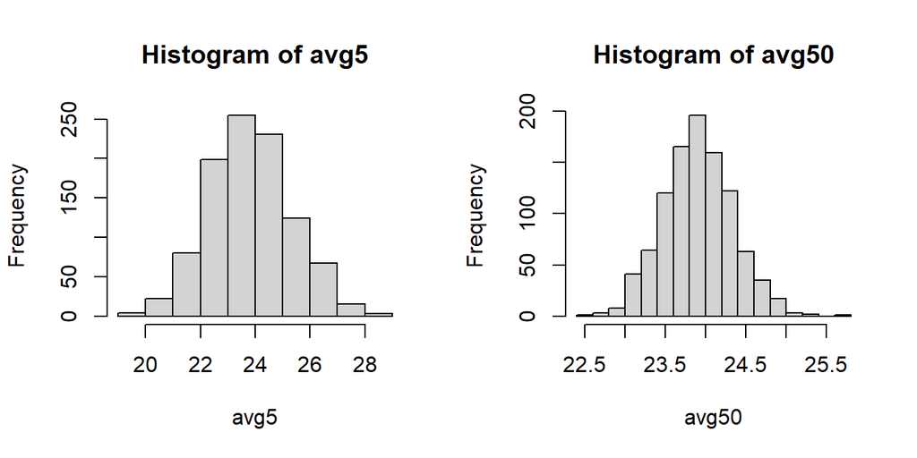

```r
par(mfrow=c(1,2))
hist(avg5)
hist(avg50)
```

Now that we created the vectors, we want to know what the proportion between X and Y is for the vector with the sample size of 50. Let’s assume X is 23 and Y is 25.

```r
mean(avg50<=25) - mean(avg50<=23)
```

```
## [1] 0.982
```

*98.2% of the data lies between 23 and 25.*  
Instead of using the “mean” we can use **“pnorm(x,m,stdv)”** or **“pnorm((x-m) / stdv)”** (Standardized Unit Z) to find the proporting of observations below x given a normal distribution with mean m and standard deviation of stdv.

```r
stdv <- sd(avg50)
m <- mean(avg50)
a <- pnorm(25,m,stdv) - pnorm(23,m,stdv)
b <- pnorm((25-m)/stdv) - pnorm((23-m/stdv))
a
```

```
## [1] 0.9766827
```

*97.66827% of the data lies between 23 and 25, assuming the avg50 follows a normal distribution*

### 2. Population, parameters and Sample Estimation

Let’s assume, we don’t have access to the population and we have to pay a certain amount of money to measure each sample. We need to take a sample and infer the measurement.  
We want to see if men are taller than women. We can’t measure all population so we will use statistical inference and measure the value for the sample. *(Population Average, Observation & Sample Average)* –> How do we know how close the sample average is to the population average? **–> Central Limit Theorem**

### 3. Central Limit Theorem

**Central Limit Theorem (CLT)** describes that **when the sample size (N) is large, the average of a random sample will follow a normal distribution** with the population mean and standard deviation (standard error) of population standard deviation divided by square root of the sample size. When the sample size is larger, the standard error is smaller (since we divide it by sample size)
Assume we want to see if the height of male and female are the same. When the null hypothesis is true, meaning there is no difference in heights, the difference in the distribution of female height (normal) and distribution of male height (normal) will be N(0,1). (mean is 0 since we assume they are the same)
$$\displaystyle \frac {\overline{Y}-\overline{X}}{\sqrt{ \displaystyle \frac {\sigma^2_{y}}{N} + \displaystyle \frac {\sigma^2_{x}}{M}}} \sim N(0,1)$$
In the next chapter, we will use t-test to prove this.

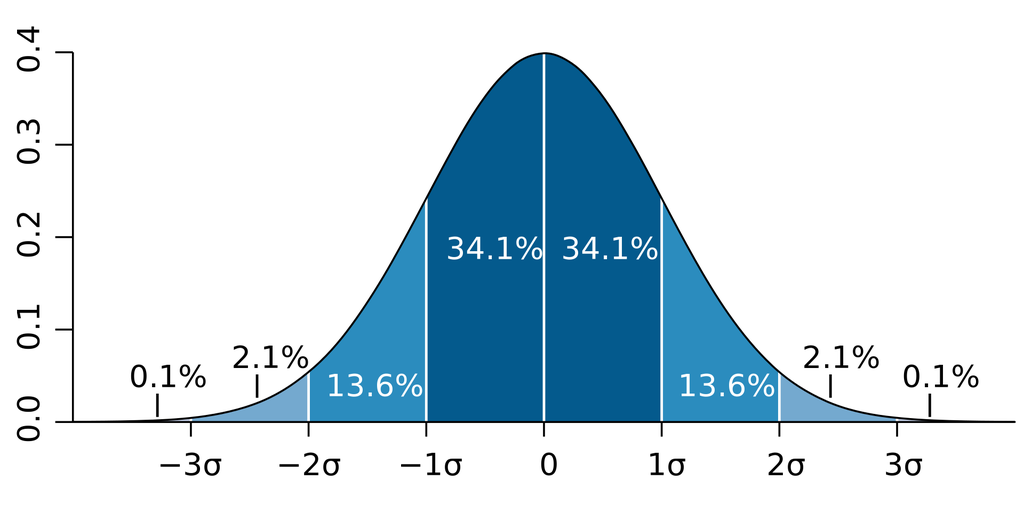

Figure above illustrates the proportion of random variables that falls within the N standard deviation away from its mean.  
Going back to our example, we will look into the weight data from mice.

First, we create numeric vectors for each group.

```r
maleControl <- weightMice[weightMice$Sex=="M" & weightMice$Diet=="chow","Bodyweight"]
maleHF <- weightMice[weightMice$Sex=="M" & weightMice$Diet=="hf","Bodyweight"]
femaleControl <- weightMice[weightMice$Sex=="F" & weightMice$Diet=="chow","Bodyweight"]
femaleHF <- weightMice[weightMice$Sex=="F" & weightMice$Diet=="hf","Bodyweight"]
```

We use two variable ‘from’ and ‘till’ to get the proportion of the numbers that is between from and till in the distribution. The following assumes a normal distribution. (Not measuring entire population)

```r
library(rafalib)
dat <- maleControl
no.stdv <- 3

from <- mean(dat) - popsd(dat)*no.stdv
till <- mean(dat) + popsd(dat)*no.stdv

pnorm( till, mean(dat), popsd(dat)) - pnorm( from, mean(dat), popsd(dat))
```

```
## [1] 0.9973002
```

```r
z <- (dat - mean(dat))/popsd(dat)
mean(abs(z) <=1)
```

```
## [1] 0.6950673
```

```r
mean(abs(z) <=2)
```

```
## [1] 0.9461883
```

```r
mean(abs(z) <=3)
```

```
## [1] 0.9910314
```

Using the entire population, we can see that *69.5%* of the random variables actually fall within 1 standard deviation away from the mean. It is close enough to assume that the male control group follows a normal distribution.  
We can see the above to be true by comparing the quantiles using qqplot. Note that while it is well described by normal distribution, the right tail are larger than the normal distribution values.

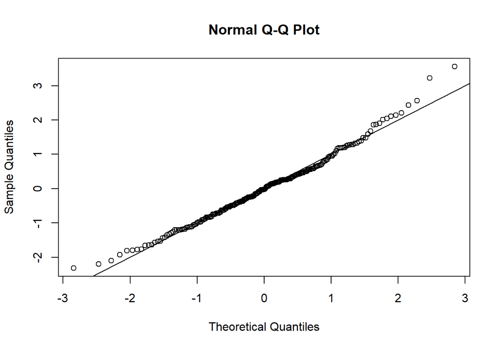

```r
qqnorm((dat - mean(dat))/popsd(dat))
abline(0,1)
```

Combined with the null hypothesis, CLT will help us get the p value and so on of the null distribution, without having access to the population In the following chapter we will learn how to use CLT to use statistical inference.

### 4. t-Test

```r
library(dplyr)
dat <- read.csv("femaleMiceWeights.csv")
control <- filter(dat, Diet == "chow") %>% select(Bodyweight) %>% unlist
treatment <- filter(dat, Diet == "hf") %>% select(Bodyweight) %>% unlist
```

```r
N <- length(treatment)
obs <- mean(treatment) - mean(control)
#standard error
se <- sqrt(var(treatment)/N + var(control)/N)
t.stat <- obs/se
#p-value
p <- 2 * (1-pnorm(t.stat))
p
```

```
## [1] 0.0398622
```

In the above one we assumed that CLT applies to the t-statistics, where as when you use t.test function (lower), we assume that t-distribution applies to the t-statistics.

```r
t.test(treatment, control)
```

```
##
##  Welch Two Sample t-test
##
## data:  treatment and control
## t = 2.0552, df = 20.236, p-value = 0.053
## alternative hypothesis: true difference in means is not equal to 0
## 95 percent confidence interval:
##  -0.04296563  6.08463229
## sample estimates:
## mean of x mean of y
##  26.83417  23.81333
```

The t.test has a bigger tail, so the p-value is bigger. When we use t-distribution, we assumes that the population is normally distributed (We can (vaguely) check by using qqnorm on the control or control group).

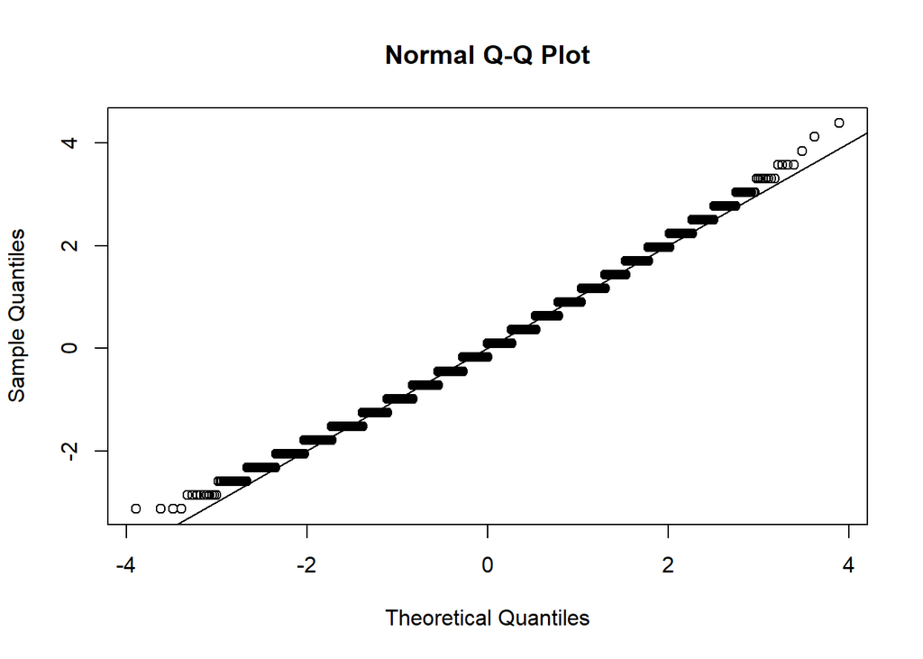

```r
set.seed(1)
n <- 100
sides <- 6
p <- 1/sides
z <- replicate(10000, {
  x <- sample(1:sides, n, replace = TRUE)
  (mean(x ==6) - p)/sqrt(p*(1-p)/n)
})
qqnorm(z)
abline(0,1)
```

```r
#proportion of times z was larger than 2 in absolute value
mean(abs(z)>2)
```

```
## [1] 0.0431
```

*Exercise 2* Until now, we assumed that we have access to the entire population, which is highly unlikely in a realistic setting. So now, we will be working with only the ‘sample’ data at hand. Using the femaleMiceWeight data (dat), we create 2 groups : x (control) and y (treatment)

```r
x <- filter(dat, Diet=="chow") %>% select(Bodyweight) %>% unlist
y <- filter(dat, Diet=="hf") %>% select(Bodyweight) %>% unlist
```

Define the parameter (mX) as the average of the control population. We estimate this parameter with the sample average (mx). The population average mX can be estimated based on the CLT : mx(sample avg) follows a *normal distribution with mean of mX (population avg) and standard deviation of sd(pop)/sqrt(12)*.  
Use the CLT to approximate the probability that our estimate mx is off by more than 2 grams from mX can be calculated as follows :

```r
sd.x <- sd(x)

2 * (1 - pnorm(2/sd.x * sqrt(12)))
```

```
## [1] 0.02189533
```

since “pnorm” can take the following form, pnorm((x-m) / stdv), where m is the mean of sample, and stdv is the standard deviation of the population. since we want to know the proportion where the mean is more than 2 grams away from the control group, we replace the x-m with **2**.
The null hypothesis would say the Diet has no effect on the weight, thus *mean(x - y) = 0*. To see if this is true, we check the standard error of the hypothesis which can be calculated as follows (In our example, N and M are both 12):
$$SE(\overline{X}-\overline{Y}) = \sqrt{\displaystyle \frac {\sigma^2_{y}}{M}+\displaystyle \frac {\sigma^2_{x}}{N}}$$

```r
obs <- mean(y) - mean(x)
se <- sqrt(var(y)/12 + var(x)/12)
t.stat <- obs/se
t.stat
```

```
## [1] 2.055174
```

```r
2*(1-pnorm(t.stat))
```

```
## [1] 0.0398622
```

t distribution is centered at 0 and has ‘degree of freedom’, which determines the size of tail. The t.test function shows the parameters, assuming it follows **t-distribution**. The above shows assuming **normal distribution**

```r
t.test(x,y)
```

```
##
##  Welch Two Sample t-test
##
## data:  x and y
## t = -2.0552, df = 20.236, p-value = 0.053
## alternative hypothesis: true difference in means is not equal to 0
## 95 percent confidence interval:
##  -6.08463229  0.04296563
## sample estimates:
## mean of x mean of y
##  23.81333  26.83417
```

We can see that the p-value under t.test and pnorm is different. The reason why the p-value under t.test is larger is due to the fact that these are two different assumptions. *The t-distribution accounts for the variability introduced by the estimation of the standard error and thus, under the null, large values are more probable under the null distribution. (directly from edx course)*